# Exercicio 3 - Machine Learning - Regressão Logística

Amanda Provetti

Uma instituição financeira nos forneceu um conjunto de dados relacionados à créditos financeiros presentes no banco de dados da instituição. A instituição está trabalhando em um projeto de ciência de dados para previsão de risco de crédito. Nós iremos participar de uma fase específica desse projeto com o objetivo de construir um classificador, que possa auxiliar na análise de risco de crédito de diversos clientes da instituição. O modelo de ML (i.e., classificador) deve prever se um determinado cliente deve ou não receber créditos de produtos financeiros ofertados pela instituição. Isso significa que teremos acesso a um conjunto de dados com informações diversas sobre inúmeros clientes da instituição. O conjunto de dados consiste em vinte (20) variáveis explanatórias que consistem em informações diversas sobre os clientes incluindo: duração e tamanho do crédito, indicadores de saldo e operações financeiras, além de dados dos clientes como idade, dependentes, emprego e até contatos como telefone. Tais informações são apresentadas com codificação que são processadas pela instituição para posteriores interpretações. Com isso, nossa tarefa consiste em lidar com os dados codificados e a variável de saída credit.rating, que indica o estado de aprovação (1) ou desaprovação (0) de crédito para cada dados de treinamento (registro) do dataset. Os pacotes listados abaixo serão fundamentais para as questões avaliativas: • library(caret) • library(ROCR) • library(e1071)

```r
install.packages("ROCR")
library(caret)
library(ROCR)
library(e1071)
```

1. Realize a importação do arquivo .csv fornecido para o RStudio

```r
dataset_credito <- read.csv("credit_dataset.csv", header = TRUE, sep = ',')
```

2. Faça a análise exploratória do dataset e verifique: ∗ i) a necessidade de normalização dos dados ∗ ii) conversão para fatores

```r
summary(dataset_credito)
```

```
 credit.rating account.balance credit.duration.months previous.credit.payment.status credit.purpose
 Min.   :0.0   Min.   :1.000   Min.   : 4.0           Min.   :1.000                  Min.   :1.000
 1st Qu.:0.0   1st Qu.:1.000   1st Qu.:12.0           1st Qu.:2.000                  1st Qu.:2.000
 Median :1.0   Median :2.000   Median :18.0           Median :2.000                  Median :3.000
 Mean   :0.7   Mean   :2.183   Mean   :20.9           Mean   :2.292                  Mean   :2.965
 3rd Qu.:1.0   3rd Qu.:3.000   3rd Qu.:24.0           3rd Qu.:3.000                  3rd Qu.:4.000
 Max.   :1.0   Max.   :3.000   Max.   :72.0           Max.   :3.000                  Max.   :4.000
 credit.amount      savings      employment.duration installment.rate marital.status    guarantor
 Min.   :  250   Min.   :1.000   Min.   :1.000       Min.   :1.000    Min.   :1.000   Min.   :1.000
 1st Qu.: 1366   1st Qu.:1.000   1st Qu.:2.000       1st Qu.:2.000    1st Qu.:1.000   1st Qu.:1.000
 Median : 2320   Median :1.000   Median :2.000       Median :3.000    Median :3.000   Median :1.000
 Mean   : 3271   Mean   :1.874   Mean   :2.446       Mean   :2.973    Mean   :2.372   Mean   :1.093
 3rd Qu.: 3972   3rd Qu.:3.000   3rd Qu.:4.000       3rd Qu.:4.000    3rd Qu.:3.000   3rd Qu.:1.000
 Max.   :18424   Max.   :4.000   Max.   :4.000       Max.   :4.000    Max.   :4.000   Max.   :2.000
 residence.duration current.assets       age        other.credits   apartment.type   bank.credits
 Min.   :1.000      Min.   :1.000   Min.   :19.00   Min.   :1.000   Min.   :1.000   Min.   :1.000
 1st Qu.:2.000      1st Qu.:1.000   1st Qu.:27.00   1st Qu.:2.000   1st Qu.:2.000   1st Qu.:1.000
 Median :3.000      Median :2.000   Median :33.00   Median :2.000   Median :2.000   Median :1.000
 Mean   :2.845      Mean   :2.358   Mean   :35.54   Mean   :1.814   Mean   :1.928   Mean   :1.367
 3rd Qu.:4.000      3rd Qu.:3.000   3rd Qu.:42.00   3rd Qu.:2.000   3rd Qu.:2.000   3rd Qu.:2.000
 Max.   :4.000      Max.   :4.000   Max.   :75.00   Max.   :2.000   Max.   :3.000   Max.   :2.000
   occupation      dependents      telephone     foreign.worker
 Min.   :1.000   Min.   :1.000   Min.   :1.000   Min.   :1.000
 1st Qu.:3.000   1st Qu.:1.000   1st Qu.:1.000   1st Qu.:1.000
 Median :3.000   Median :1.000   Median :1.000   Median :1.000
 Mean   :2.904   Mean   :1.155   Mean   :1.404   Mean   :1.037
 3rd Qu.:3.000   3rd Qu.:1.000   3rd Qu.:2.000   3rd Qu.:1.000
 Max.   :4.000   Max.   :2.000   Max.   :2.000   Max.   :2.000
```

```r
head(dataset_credito)
```

|  | credit.rating | account.balance | credit.duration.months | previous.credit.payment.status | credit.purpose | credit.amount | savings | employment.duration | installment.rate | marital.status | guarantor | residence.duration | current.assets | age | other.credits | apartment.type | bank.credits | occupation | dependents | telephone | foreign.worker |
| --- | --- | --- | --- | --- | --- | --- | --- | --- | --- | --- | --- | --- | --- | --- | --- | --- | --- | --- | --- | --- | --- |
| 1 | 1 | 1 | 18 | 3 | 2 | 1049 | 1 | 1 | 4 | 1 | 1 | 4 | 2 | 21 | 2 | 1 | 1 | 3 | 1 | 1 | 1 |
| 2 | 1 | 1 | 9 | 3 | 4 | 2799 | 1 | 2 | 2 | 3 | 1 | 2 | 1 | 36 | 2 | 1 | 2 | 3 | 2 | 1 | 1 |
| 3 | 1 | 2 | 12 | 2 | 4 | 841 | 2 | 3 | 2 | 1 | 1 | 4 | 1 | 23 | 2 | 1 | 1 | 2 | 1 | 1 | 1 |
| 4 | 1 | 1 | 12 | 3 | 4 | 2122 | 1 | 2 | 3 | 3 | 1 | 2 | 1 | 39 | 2 | 1 | 2 | 2 | 2 | 1 | 2 |
| 5 | 1 | 1 | 12 | 3 | 4 | 2171 | 1 | 2 | 4 | 3 | 1 | 4 | 2 | 38 | 1 | 2 | 2 | 2 | 1 | 1 | 2 |
| 6 | 1 | 1 | 10 | 3 | 4 | 2241 | 1 | 1 | 1 | 3 | 1 | 3 | 1 | 48 | 2 | 1 | 2 | 2 | 2 | 1 | 2 |

```r
str(dataset_credito)
```

```
'data.frame':   1000 obs. of  21 variables:
 $ credit.rating                 : int  1 1 1 1 1 1 1 1 1 1 ...
 $ account.balance               : int  1 1 2 1 1 1 1 1 3 2 ...
 $ credit.duration.months        : int  18 9 12 12 12 10 8 6 18 24 ...
 $ previous.credit.payment.status: int  3 3 2 3 3 3 3 3 3 2 ...
 $ credit.purpose                : int  2 4 4 4 4 4 4 4 3 3 ...
 $ credit.amount                 : int  1049 2799 841 2122 2171 2241 3398 1361 1098 3758 ...
 $ savings                       : int  1 1 2 1 1 1 1 1 1 3 ...
 $ employment.duration           : int  1 2 3 2 2 1 3 1 1 1 ...
 $ installment.rate              : int  4 2 2 3 4 1 1 2 4 1 ...
 $ marital.status                : int  1 3 1 3 3 3 3 3 1 1 ...
 $ guarantor                     : int  1 1 1 1 1 1 1 1 1 1 ...
 $ residence.duration            : int  4 2 4 2 4 3 4 4 4 4 ...
 $ current.assets                : int  2 1 1 1 2 1 1 1 3 4 ...
 $ age                           : int  21 36 23 39 38 48 39 40 65 23 ...
 $ other.credits                 : int  2 2 2 2 1 2 2 2 2 2 ...
 $ apartment.type                : int  1 1 1 1 2 1 2 2 2 1 ...
 $ bank.credits                  : int  1 2 1 2 2 2 2 1 2 1 ...
 $ occupation                    : int  3 3 2 2 2 2 2 2 1 1 ...
 $ dependents                    : int  1 2 1 2 1 2 1 2 1 1 ...
 $ telephone                     : int  1 1 1 1 1 1 1 1 1 1 ...
 $ foreign.worker                : int  1 1 1 2 2 2 2 2 1 1 ...
```

3. Considerando o item 2) identifique quais são as variáveis numéricas e os fatores. ∗ Crie duas funções: para normalização e conversão em fatores.

```r
factor_conversion <- function(df , variaveis){
  for (variavel in variaveis){
    df[[variavel]] <- as.factor(df[[variavel]])
  }
  return(df)
}

#Feature scaling
normalizar_features <- function(df, variables){
  for (variable in variables){
    df[[variable]] <- scale(df[[variable]], center = T, scale = T)
  }
  return(df)
}
```

```r
numeric_vars <- c("credit.duration.months", "age", "credit.amount")
dataset_credito_normalizado <- normalizar_features(dataset_credito, numeric_vars)
categorical_vars <- c('credit.rating', 'account.balance', 'previous.credit.payment.status',
                      'credit.purpose', 'savings', 'employment.duration', 'installment.rate',
                      'marital.status', 'guarantor', 'residence.duration', 'current.assets',
                      'other.credits', 'apartment.type', 'bank.credits', 'occupation',
                      'dependents', 'telephone', 'foreign.worker')
dataset_credito_normalizado_factor <- factor_conversion(dataset_credito_normalizado, categorical_vars)
str(dataset_credito_normalizado_factor)
```

```
'data.frame':   1000 obs. of  21 variables:
 $ credit.rating                 : Factor w/ 2 levels "0","1": 2 2 2 2 2 2 2 2 2 2 ...
 $ account.balance               : Factor w/ 3 levels "1","2","3": 1 1 2 1 1 1 1 1 3 2 ...
 $ credit.duration.months        : num [1:1000, 1] -0.241 -0.987 -0.738 -0.738 -0.738 ...
  ..- attr(*, "scaled:center")= num 20.9
  ..- attr(*, "scaled:scale")= num 12.1
 $ previous.credit.payment.status: Factor w/ 3 levels "1","2","3": 3 3 2 3 3 3 3 3 3 2 ...
 $ credit.purpose                : Factor w/ 4 levels "1","2","3","4": 2 4 4 4 4 4 4 4 3 3 ...
 $ credit.amount                 : num [1:1000, 1] -0.787 -0.167 -0.861 -0.407 -0.39 ...
  ..- attr(*, "scaled:center")= num 3271
  ..- attr(*, "scaled:scale")= num 2823
 $ savings                       : Factor w/ 4 levels "1","2","3","4": 1 1 2 1 1 1 1 1 1 3 ...
 $ employment.duration           : Factor w/ 4 levels "1","2","3","4": 1 2 3 2 2 1 3 1 1 1 ...
 $ installment.rate              : Factor w/ 4 levels "1","2","3","4": 4 2 2 3 4 1 1 2 4 1 ...
 $ marital.status                : Factor w/ 3 levels "1","3","4": 1 2 1 2 2 2 2 2 1 1 ...
 $ guarantor                     : Factor w/ 2 levels "1","2": 1 1 1 1 1 1 1 1 1 1 ...
 $ residence.duration            : Factor w/ 4 levels "1","2","3","4": 4 2 4 2 4 3 4 4 4 4 ...
 $ current.assets                : Factor w/ 4 levels "1","2","3","4": 2 1 1 1 2 1 1 1 3 4 ...
 $ age                           : num [1:1000, 1] -1.2809 0.0403 -1.1048 0.3046 0.2165 ...
  ..- attr(*, "scaled:center")= num 35.5
  ..- attr(*, "scaled:scale")= num 11.4
 $ other.credits                 : Factor w/ 2 levels "1","2": 2 2 2 2 1 2 2 2 2 2 ...
 $ apartment.type                : Factor w/ 3 levels "1","2","3": 1 1 1 1 2 1 2 2 2 1 ...
 $ bank.credits                  : Factor w/ 2 levels "1","2": 1 2 1 2 2 2 2 1 2 1 ...
 $ occupation                    : Factor w/ 4 levels "1","2","3","4": 3 3 2 2 2 2 2 2 1 1 ...
 $ dependents                    : Factor w/ 2 levels "1","2": 1 2 1 2 1 2 1 2 1 1 ...
 $ telephone                     : Factor w/ 2 levels "1","2": 1 1 1 1 1 1 1 1 1 1 ...
 $ foreign.worker                : Factor w/ 2 levels "1","2": 1 1 1 2 2 2 2 2 1 1 ...
```

4. Realize a divisão do conjunto de treino e teste em 60/40.

```r
size <- nrow(dataset_credito_normalizado_factor)
index_training = sample(1:size, size = 0.6*size)
training_data = dataset_credito_normalizado_factor[index_training,]
test_data     = dataset_credito_normalizado_factor[-index_training,]
```

5. Para reprodução dos resultados use o set.seed(100).

```r
set.seed(100)
```

6. Construa e treine o modelo preditivo de ML baseado em regressão logística.

```r
equation <- "credit.rating ~ ."
equation <- as.formula(equation)
modelo_ML_logistic_1 <- glm(equation, data = training_data, family = "binomial")
```

– 7) Faça a síntese do modelo e interprete os seus resultados.

```r
summary(modelo_ML_logistic_1)
```

```
Call:
glm(formula = equation, family = "binomial", data = training_data)

Deviance Residuals:
    Min       1Q   Median       3Q      Max
-2.8529  -0.5859   0.3629   0.6702   1.9076

Coefficients:
                                Estimate Std. Error z value Pr(>|z|)
(Intercept)                     -1.46588    1.04485  -1.403  0.16063
account.balance2                 0.61451    0.28265   2.174  0.02970 *
account.balance3                 1.75150    0.28737   6.095 1.09e-09 ***
credit.duration.months          -0.29683    0.14619  -2.030  0.04231 *
previous.credit.payment.status2  1.24423    0.41801   2.977  0.00292 **
previous.credit.payment.status3  1.01738    0.43156   2.357  0.01840 *
credit.purpose2                 -0.61414    0.51330  -1.196  0.23152
credit.purpose3                 -0.62164    0.47686  -1.304  0.19237
credit.purpose4                 -1.07610    0.45697  -2.355  0.01853 *
credit.amount                   -0.32372    0.16145  -2.005  0.04496 *
savings2                         0.19721    0.37007   0.533  0.59409
savings3                         1.05130    0.42471   2.475  0.01331 *
savings4                         1.15210    0.35936   3.206  0.00135 **
employment.duration2             0.26996    0.31605   0.854  0.39301
employment.duration3             0.97737    0.39002   2.506  0.01221 *
employment.duration4            -0.05343    0.36729  -0.145  0.88434
installment.rate2               -0.26571    0.41504  -0.640  0.52204
installment.rate3               -0.88532    0.44592  -1.985  0.04710 *
installment.rate4               -1.28316    0.39957  -3.211  0.00132 **
marital.status3                  0.85269    0.26485   3.219  0.00128 **
marital.status4                  0.33518    0.40701   0.824  0.41021
guarantor2                       0.44868    0.40880   1.098  0.27240
residence.duration2             -0.34567    0.38807  -0.891  0.37307
residence.duration3             -0.05320    0.43010  -0.124  0.90155
residence.duration4              0.18145    0.39235   0.462  0.64374
current.assets2                 -0.49183    0.33597  -1.464  0.14322
current.assets3                 -0.31912    0.32310  -0.988  0.32330
current.assets4                 -1.16004    0.49042  -2.365  0.01801 *
age                              0.22443    0.14897   1.507  0.13194
other.credits2                   0.09741    0.30084   0.324  0.74609
apartment.type2                  0.68156    0.31181   2.186  0.02883 *
apartment.type3                  0.89410    0.58130   1.538  0.12403
bank.credits2                    0.49093    0.33942   1.446  0.14807
occupation2                      0.62595    0.83540   0.749  0.45369
occupation3                      0.58448    0.80352   0.727  0.46698
occupation4                      0.58415    0.83837   0.697  0.48595
dependents2                     -0.41057    0.32657  -1.257  0.20868
telephone2                       0.45006    0.27435   1.640  0.10091
foreign.worker2                  1.63917    0.84399   1.942  0.05212 .
---
Signif. codes:  0 ‘***’ 0.001 ‘**’ 0.01 ‘*’ 0.05 ‘.’ 0.1 ‘ ’ 1

(Dispersion parameter for binomial family taken to be 1)

    Null deviance: 717.14  on 599  degrees of freedom
Residual deviance: 518.13  on 561  degrees of freedom
AIC: 596.13

Number of Fisher Scoring iterations: 5
```

8. Faça as predições para os dados de teste e avalie os resultados com a matriz de confusão.

```r
test_features <- test_data[,-1]
test_target   <- test_data[,1]
previsao_teste <- predict(modelo_ML_logistic_1, test_data, type = 'response')
previsao_teste <- round(previsao_teste)
summary(previsao_teste)
```

```
   Min. 1st Qu.  Median    Mean 3rd Qu.    Max.
   0.00    1.00    1.00    0.76    1.00    1.00
```

```r
previsao_teste_data <- data.frame(previsao_teste, test_target)
colnames(previsao_teste_data) <- c('PrevisÃ£o','Target')
summary(previsao_teste_data)
```

```
   PrevisÃ£o    Target
 Min.   :0.00   0:129
 1st Qu.:1.00   1:271
 Median :1.00
 Mean   :0.76
 3rd Qu.:1.00
 Max.   :1.00
```

```r
cm_modelo_1 <- confusionMatrix(table(data = previsao_teste, reference = test_target), positive = "1")
cm_modelo_1
```

```
Confusion Matrix and Statistics

    reference
data   0   1
   0  58  38
   1  71 233

               Accuracy : 0.7275
                 95% CI : (0.681, 0.7706)
    No Information Rate : 0.6775
    P-Value [Acc > NIR] : 0.017449

                  Kappa : 0.3316

 Mcnemar's Test P-Value : 0.002176

            Sensitivity : 0.8598
            Specificity : 0.4496
         Pos Pred Value : 0.7664
         Neg Pred Value : 0.6042
             Prevalence : 0.6775
         Detection Rate : 0.5825
   Detection Prevalence : 0.7600
      Balanced Accuracy : 0.6547

       'Positive' Class : 1
```

– 9) Use a função varImp do pacote caret para descobrir as variáveis explanatórias mais relevantes para o modelo.

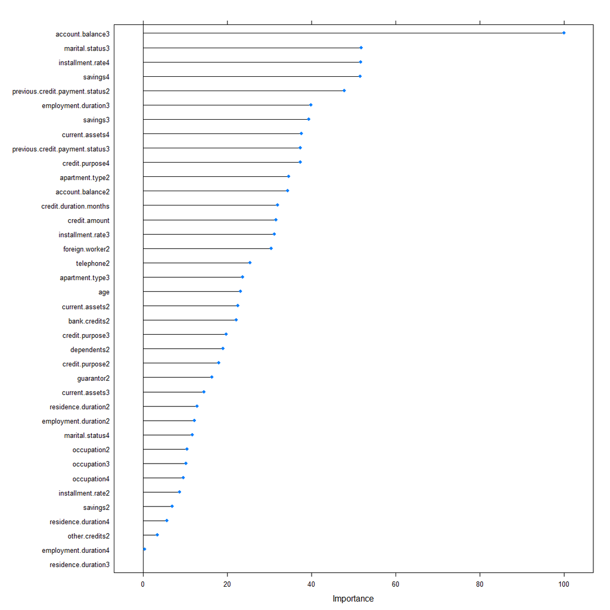

```r
controle_procedimento      <- trainControl(method = "repeatedcv", number = 10, repeats = 2)
modelo_ML_controle_traning <- train(equation, data = training_data, method = 'glm', trControl = controle_procedimento)
feature_selection = varImp(modelo_ML_controle_traning, scale = TRUE)
plot(feature_selection)
```

10. Obtenha a curva ROC do classificador antes da análise varImp

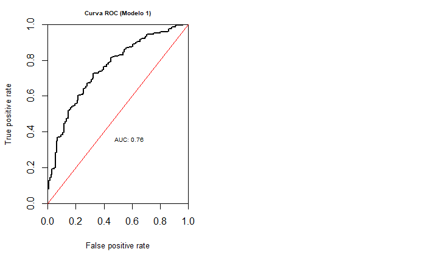

```r
previsao_teste_modelo_1 <- predict(modelo_ML_logistic_1, test_data, type = 'response')
previsoes_finais_modelo_1 <- prediction(previsao_teste_modelo_1, test_target)

plot.roc.curve <- function(predictions, title.text){
  perf <- performance(predictions, "tpr", "fpr")
  plot(perf,col = "black",lty = 1, lwd = 2,
       main = title.text, cex.main = 0.6, cex.lab = 0.8,xaxs = "i", yaxs = "i")
  abline(0,1, col = "red")
  auc <- performance(predictions,"auc")
  auc <- unlist(slot(auc, "y.values"))
  auc <- round(auc,2)
  legend(0.4,0.4,legend = c(paste0("AUC: ",auc)), cex = 0.6, bty = "n", box.col = "white")
}

# Plot - quantidade de grÃ¡ficos na paleta grÃ¡fica do R
par(mfrow = c(1, 2))
plot.roc.curve(previsoes_finais_modelo_1, title.text = "Curva ROC (Modelo 1)")
```

11. Obtenha a curva ROC do classificador após da análise com varImp

```r
equation_nova <- "credit.rating ~ account.balance + credit.purpose + previous.credit.payment.status + savings + credit.duration.months"
```

[output not shown]

```r
equation_nova <- as.formula(equation_nova)
modelo_ML_logistic_2 <- glm(equation_nova, data = training_data, family = "binomial")
modelo_ML_logistic_2
```

```
Call:  glm(formula = equation_nova, family = "binomial", data = training_data)

Coefficients:
                    (Intercept)                 account.balance2                 account.balance3
                        -0.5774                           0.4521                           1.6745
                credit.purpose2                  credit.purpose3                  credit.purpose4
                        -0.4938                          -0.6363                          -0.7285
previous.credit.payment.status2  previous.credit.payment.status3                         savings2
                         1.0955                           1.2928                           0.2444
                       savings3                         savings4           credit.duration.months
                         0.9432                           1.1178                          -0.4515

Degrees of Freedom: 599 Total (i.e. Null);  588 Residual
Null Deviance:      717.1
Residual Deviance: 584.2    AIC: 608.2
```

```r
summary(modelo_ML_logistic_2)
```

```
Call:
glm(formula = equation_nova, family = "binomial", data = training_data)

Deviance Residuals:
    Min       1Q   Median       3Q      Max
-2.5474  -0.8025   0.4814   0.7460   1.8994

Coefficients:
                                Estimate Std. Error z value Pr(>|z|)
(Intercept)                      -0.5774     0.4980  -1.159 0.246296
account.balance2                  0.4521     0.2499   1.809 0.070430 .
account.balance3                  1.6745     0.2606   6.426 1.31e-10 ***
credit.purpose2                  -0.4938     0.4421  -1.117 0.263973
credit.purpose3                  -0.6363     0.4097  -1.553 0.120398
credit.purpose4                  -0.7285     0.4032  -1.807 0.070785 .
previous.credit.payment.status2   1.0955     0.3450   3.175 0.001496 **
previous.credit.payment.status3   1.2928     0.3599   3.592 0.000328 ***
savings2                          0.2444     0.3292   0.743 0.457733
savings3                          0.9432     0.3922   2.405 0.016164 *
savings4                          1.1178     0.3210   3.482 0.000497 ***
credit.duration.months           -0.4515     0.1055  -4.280 1.87e-05 ***
---
Signif. codes:  0 ‘***’ 0.001 ‘**’ 0.01 ‘*’ 0.05 ‘.’ 0.1 ‘ ’ 1

(Dispersion parameter for binomial family taken to be 1)

    Null deviance: 717.14  on 599  degrees of freedom
Residual deviance: 584.17  on 588  degrees of freedom
AIC: 608.17

Number of Fisher Scoring iterations: 5
```

```r
previsao_teste_2 <- predict(modelo_ML_logistic_2, test_data, type = 'response')
previsao_teste_2 <- round(previsao_teste_2)

previsao_teste_2_data <- data.frame(previsao_teste_2, test_target)
colnames(previsao_teste_2_data) <- c('PrevisÃ£o Nova','Target')
```

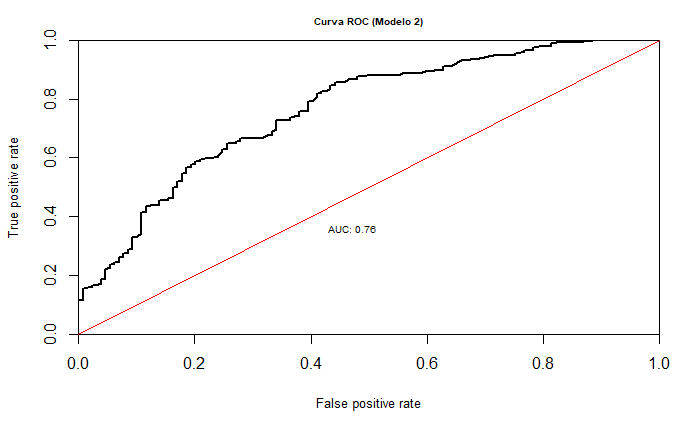

```r
cm_modelo_2 <- confusionMatrix(table(data = previsao_teste_2, reference = test_target), positive = "1")

previsao_teste_modelo_2 <- predict(modelo_ML_logistic_2, test_data, type = 'response')

previsoes_finais_modelo_2 <- prediction(previsao_teste_modelo_2, test_target)

plot.roc.curve <- function(predictions, title.text){
  perf <- performance(predictions, "tpr", "fpr")
  plot(perf,col = "black",lty = 1, lwd = 2,
       main = title.text, cex.main = 0.6, cex.lab = 0.8,xaxs = "i", yaxs = "i")
  abline(0,1, col = "red")
  auc <- performance(predictions,"auc")
  auc <- unlist(slot(auc, "y.values"))
  auc <- round(auc,2)
  legend(0.4,0.4,legend = c(paste0("AUC: ",auc)), cex = 0.6, bty = "n", box.col = "white")
}

plot.roc.curve(previsoes_finais_modelo_2, title.text = "Curva ROC (Modelo 2)")
```